# Módulo 5. Descriptores de forma: Transformada Elíptica de Fourier

Curso corto: Análisis de contornos de otolitos con R

Luis Cubillos

Noviembre 2026

# Objetivos del módulo

1. Entender el contorno como una **suma de elipses** (armónicos).
2. Calcular los coeficientes de Fourier elíptico con `efourier()` y reconstruir el contorno con `iefourier()`.
3. **Normalizar** los coeficientes (tamaño, rotación, punto de inicio) con `NEF()`.
4. Construir la **matriz de coeficientes** de todos los otolitos.
5. Elegir el **número de armónicos** a retener.

```r
cx <- read.csv("datos/contornos_3zonas.csv")      # módulo 4
A  <- largo_a_array(cx)                           # arreglo 50 x 2 x 67
zona <- factor(cx$zona[cx$punto == 1], levels = c("Ch", "Ay", "Ma"))
M  <- A[, , 1]                                    # un otolito de Chiloé
```

# Análisis de Fourier de contornos

# Idea

Una función periódica se descompone en una suma de senos y cosenos de frecuencia creciente (**armónicos**). Para un contorno cerrado hay tres opciones (Claude 2008, secc. 5.2):

1. **Radios** desde el centroide en función del ángulo, *r(θ)*.
2. **Ángulo tangente** en función del perímetro, *φ(t)*.
3. **Elíptico**: descomponer **por separado** *x(t)* e *y(t)* en función de la abscisa curvilínea *t* (Kuhl y Giardina 1982).

El Fourier elíptico no requiere que el contorno sea “estrellado” desde el centroide y es el estándar en otolitos.

# Fourier elíptico

$$x(t) = \frac{a_0}{2} +
\sum_{n=1}^{N}\left[a_n\cos\frac{2\pi nt}{T} + b_n\sin\frac{2\pi
nt}{T}\right]$$

$$y(t) = \frac{c_0}{2} +
\sum_{n=1}^{N}\left[c_n\cos\frac{2\pi nt}{T} + d_n\sin\frac{2\pi
nt}{T}\right]$$

- *t*: distancia recorrida sobre el contorno; *T*: perímetro.
- Cada armónico *n* es una **elipse** con 4 coeficientes $(a_n, b_n, c_n, d_n)$.
- $a_0, c_0$: posición del centroide.

Estimación discreta con *p* puntos (Kuhl y Giardina 1982):

$$a_n =
\frac{T}{2\pi^2n^2}\sum_{i=1}^{p}\frac{\Delta x_i}{\Delta
t_i}\left[\cos\frac{2\pi n t_i}{T}-\cos\frac{2\pi n
t_{i-1}}{T}\right]$$

y análogamente $b_n$ (seno), $c_n$ y $d_n$ (con $\Delta y_i$).

# `efourier()` (Claude 2008, función 5.8)

```r
ef <- efourier(M)          # por defecto n = p/2 = 25 armónicos
str(ef)
```

```
#> List of 6
#>  $ ao: num -4.64
#>  $ co: num 1.11
#>  $ an: num [1:25] -436.91 -5.39 -37.07 -3.9 -5.92 ...
#>  $ bn: num [1:25] -44.39 -7.21 -12.89 -1.56 -4.31 ...
#>  $ cn: num [1:25] -23.16 3.19 13.82 -3 2.16 ...
#>  $ dn: num [1:25] -201.71 25.9 -25.4 -7.06 -8.08 ...
```

```r
round(with(ef, cbind(an, bn, cn, dn))[1:5, ], 2)
```

```
#>           an     bn     cn      dn
#> [1,] -436.91 -44.39 -23.16 -201.71
#> [2,]   -5.39  -7.21   3.19   25.90
#> [3,]  -37.07 -12.89  13.82  -25.40
#> [4,]   -3.90  -1.56  -3.00   -7.06
#> [5,]   -5.92  -4.31   2.16   -8.08
```

# Cada armónico es una elipse

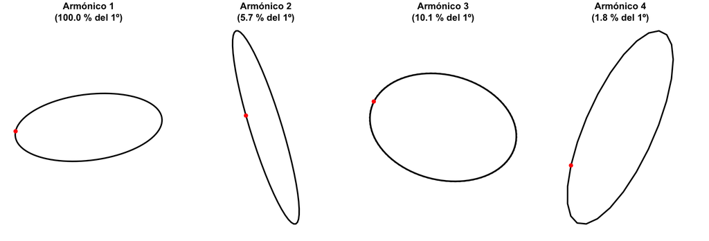

```r
tam <- sqrt(ef$an^2 + ef$bn^2 + ef$cn^2 + ef$dn^2)    # tamaño de cada elipse
par(mfrow = c(1, 4), mar = c(1, 1, 2.5, 1))
for (n in 1:4) {
  cf <- function(v) replace(numeric(25), n, v[n])     # solo el armónico n
  e  <- iefourier(cf(ef$an), cf(ef$bn), cf(ef$cn), cf(ef$dn), 25, 100)
  plot(e, type = "l", asp = 1, axes = FALSE, xlab = "", ylab = "", lwd = 2,
       main = sprintf("Armónico %d\n(%.1f %% del 1º)", n, 100 * tam[n] / tam[1]))
  points(e$x[1], e$y[1], pch = 19, col = "red")       # posición en t = 0
}
```

# Reconstrucción con `iefourier()` (función 5.9)

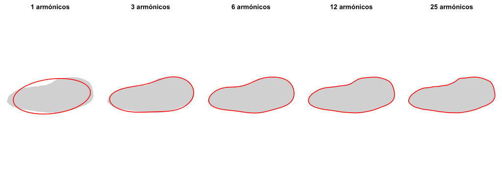

```r
par(mfrow = c(1, 5), mar = c(0.5, 0.5, 2, 0.5))
for (k in c(1, 3, 6, 12, 25)) {
  r <- iefourier(ef$an, ef$bn, ef$cn, ef$dn, k, 200, ef$ao, ef$co)
  plot(M, type = "n", asp = 1, axes = FALSE, xlab = "", ylab = "", main = paste(k, "armónicos"))
  polygon(M, col = "grey85", border = NA)
  lines(c(r$x, r$x[1]), c(r$y, r$y[1]), col = "red", lwd = 1.5)
}
```

Los armónicos altos contienen sobre todo **ruido de digitalización**.

# Error de reconstrucción

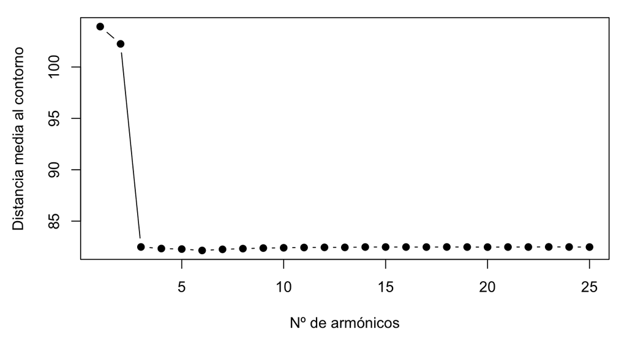

```r
err <- sapply(1:25, function(k) {
  r <- iefourier(ef$an, ef$bn, ef$cn, ef$dn, k, 50, ef$ao, ef$co)
  mean(sqrt(rowSums((cbind(r$x, r$y) - M)^2)))
})
par(mar = c(4.5, 4.5, 1, 1))
plot(1:25, err, type = "b", pch = 19, xlab = "Nº de armónicos",
     ylab = "Distancia media al contorno")
```

# Normalización

# ¿Por qué normalizar?

Los coeficientes de `efourier()` dependen del **tamaño**, la **orientación**, la **posición** y el **punto de inicio** del contorno. Para comparar formas hay que eliminar esos efectos.

`NEF()` (Claude 2008, función 5.10; Ferson et al. 1985) usa la **primera elipse**:

$$\begin{pmatrix}A_n & B_n\\ C_n &
D_n\end{pmatrix} = \frac{1}{\text{escala}}
\begin{pmatrix}\cos\psi & \sin\psi\\ -\sin\psi &
\cos\psi\end{pmatrix}
\begin{pmatrix}a_n & b_n\\ c_n & d_n\end{pmatrix}
\begin{pmatrix}\cos n\theta & -\sin n\theta\\ \sin n\theta &
\cos n\theta\end{pmatrix}$$

- **escala**: semieje mayor de la 1ª elipse → elimina el tamaño;
- $\psi$: orientación de la 1ª elipse → elimina la rotación;
- $\theta$: desfase del punto inicial respecto del semieje mayor → elimina el punto de inicio;
- se omiten $a_0, c_0$ → elimina la posición.

# Demostración: mismo otolito, distinta posición

```r
rot <- function(M, a) M %*% matrix(c(cos(a), sin(a), -sin(a), cos(a)), 2, 2)
M_b <- rot(M, pi / 4) * 2.5 + 300              # rotado, agrandado y trasladado
M_c <- M[c(11:50, 1:10), ]                     # otro punto de inicio
coefs <- function(M) { N <- NEF(M); round(c(N$A[2:3], N$B[2:3], N$C[2:3], N$D[2:3]), 4) }
rbind(original = coefs(M), transformado = coefs(M_b), otro_inicio = coefs(M_c))
```

```
#>                [,1]   [,2]   [,3]    [,4]    [,5]    [,6]    [,7]   [,8]
#> original     0.0134 0.0871 0.0051 -0.0038 -0.0268 -0.0127 -0.0546 0.0664
#> transformado 0.0134 0.0871 0.0051 -0.0038 -0.0268 -0.0127 -0.0546 0.0664
#> otro_inicio  0.0134 0.0871 0.0051 -0.0038 -0.0268 -0.0127 -0.0546 0.0664
```

```r
round(rbind(original = efourier(M)$an[2:3], transformado = efourier(M_b)$an[2:3]), 1)
```

```
#>              [,1]  [,2]
#> original     -5.4 -37.1
#> transformado -3.9 -41.1
```

Los coeficientes **normalizados** son iguales; los **crudos**, no.

# Fe de erratas de Claude (2008, pp. 225–226)

- La fórmula clásica no siempre identifica el **semieje mayor**; el punto de inicio puede caer en cualquiera de los **dos polos** de la 1ª elipse.
- La versión de `NEF()` del curso **incluye la corrección** (restringe el desfase a $[-\pi/2, \pi/2]$), suponiendo que el punto inicial está en una región **similar** del contorno en todos los otolitos.

Por eso, aun con normalización, conviene **digitalizar siempre desde la misma zona** (p. ej., el rostro) y con la misma orientación (módulo 3).

# Coeficientes normalizados de un otolito

```r
N <- NEF(M)
round(rbind(A = N$A[1:5], B = N$B[1:5], C = N$C[1:5], D = N$D[1:5]), 4)
```

```
#>     [,1]    [,2]    [,3]    [,4]    [,5]
#> A 1.0000  0.0134  0.0871  0.0110  0.0174
#> B 0.0000  0.0051 -0.0038 -0.0012 -0.0005
#> C 0.0000 -0.0268 -0.0127  0.0136  0.0073
#> D 0.4462 -0.0546  0.0664  0.0092  0.0166
```

Tras normalizar: $A_1 = 1$ y $B_1 = C_1 = 0$ son **constantes**; $D_1$ es la razón ancho/largo de la 1ª elipse. El 1er armónico se **excluye** del análisis multivariado (salvo, eventualmente, $D_1$).

# Matriz de coeficientes

# Todos los otolitos

```r
nh <- 25
coef <- t(apply(A, 3, function(m) { N <- NEF(m); c(N$A, N$B, N$C, N$D) }))
colnames(coef) <- paste0(rep(c("A", "B", "C", "D"), each = nh), 1:nh)
dim(coef)                       # otolitos x (4 x 25)
```

```
#> [1]  67 100
```

```r
round(coef[1:3, c("A2", "B2", "C2", "D2", "A3")], 4)
```

```
#>          A2      B2      C2      D2     A3
#> Ch01 0.0134  0.0051 -0.0268 -0.0546 0.0871
#> Ch02 0.0093  0.0124 -0.0563 -0.0603 0.0910
#> Ch03 0.0093 -0.0024 -0.0423 -0.0457 0.0838
```

Orden de columnas: A1…A25, B1…B25, C1…C25, D1…D25.

# ¿Cuántos armónicos retener? Poder acumulado

Claude (2008, p. 245): el **poder** de cada armónico es la suma de los cuadrados de sus coeficientes; mide cuánto de la **forma** reconstruye.

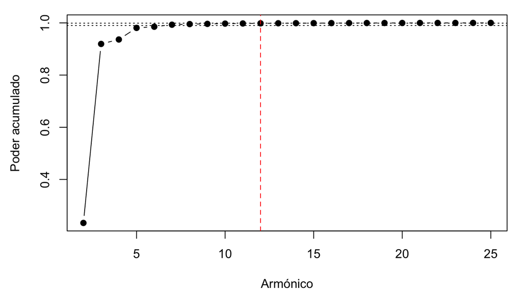

```r
power <- rowSums(matrix(colSums(coef^2), nh, 4))    # suma de A^2+B^2+C^2+D^2 por armónico
poder <- cumsum(power[-1]) / sum(power[-1])          # sin el 1er armónico
par(mar = c(4.5, 4.5, 1, 1))
plot(2:nh, poder, type = "b", pch = 19, ylim = c(min(poder), 1),
     xlab = "Armónico", ylab = "Poder acumulado")
abline(h = c(0.99, 0.999), lty = 3); abline(v = 12, lty = 2, col = "red")
```

```r
min(which(poder >= 0.99)) + 1       # primer armónico que alcanza 99 % del poder
```

```
#> [1] 7
```

El criterio de **varianza** entre individuos se ve en el módulo 6.

# Guardar los coeficientes

```r
coef_df <- data.frame(id = dimnames(A)[[3]], zona = zona, coef)
write.csv(coef_df, "datos/coef_nef_3zonas.csv", row.names = FALSE)
```

# Resumen y ejercicio

50 puntos (x, y) → `efourier()` → 25 armónicos × 4 coeficientes → `NEF()` → coeficientes invariantes → matriz otolitos × coeficientes

**Ejercicio**

1. Reconstruya el primer otolito de Aysén con 4, 8 y 12 armónicos.
2. Verifique que `NEF()` da los mismos coeficientes si el contorno se recorre en **sentido inverso** (`M[50:1, ]`). ¿Qué ocurre?
3. ¿Con cuántos armónicos se alcanza 99.9 % del poder?

Ferson, S., Rohlf, F.J. y Koehn, R.K. (1985). Measuring shape variation of two-dimensional outlines. *Syst. Zool.* 34: 59–68. Kuhl, F.P. y Giardina, C.R. (1982). *Comput. Graph. Image Process.* 18: 236–258.